# GDP_Analysis

Leticia Valadez

March 23, 2017

## Introduction

#### This report analyzes Gross Domestic Product (GDP) based on GDP value ranking obtained from the World Bank (1) and income group classification obtained from the World Bank EdStats All Indicator Query (2). Gross domestic product is primary way to measure a country’s economy and is determined by the total value of everything produced in the country. The “size” of the economy is a direct reference to the GDP (3). This analysis will address questions about the various countries’ economy for year 2012. The subsets of the GDP data used for this report for the GPD ranking and income group data can be downloaded, respectively, from the following links:

https://d396qusza40orc.cloudfront.net/getdata%2Fdata%2FGDP.csv https://d396qusza40orc.cloudfront.net/getdata%2Fdata%2FEDSTATS_Country.csv

```r
knitr::opts_chunk$set(fig.width=12, fig.height=8, fig.path='Analysis/GDPdistribution',
                      echo=TRUE, warning=FALSE, message=TRUE)
```

```r
source("./mainHelper.R")
```

```
##
##  C:\Users\tish\AppData\Local\Temp\RtmpOm383v\downloaded_packages
```

```
##
##  C:\Users\tish\AppData\Local\Temp\RtmpOm383v\downloaded_packages
```

## GDP Ranking Data

#### The GDP ranking file only includes rankings for those economies with confirmed GDP estimates. It has four columns of data with no header for the first column and “Ranking”, “Economy”, and “(millions of US dollars)” for the other columns. The headers are redefined in the code after reading the files into environment to “CountryCode”, “Ranking”, “Country”, and “GDPvalue”. The first four rows are deleted since they mainly empty except for the comment “Gross domestic product 2012” in one data cell. There is an empty column in between the other columns that is removed. The ranking data are converted to an integer data type for analysis. For the “GDPvalue” variable, the commas are removed and converted to an integer data type.

#### 1. CountryCode – 3-digit country code

#### 2. Ranking – Ranks countries with confirmed GDP

#### 3. Country (Economy) – Name of country but sometimes not complete proper long name of country.

#### 4. GDPvalue((millions of US dollars)) – Monetary GPD value in US dollars in millions.

#### • Problems with the data –

#### 1. The data set contains countries or regions with no ranking but GDP values.

#### 2. Country codes are giving to regions or other types of classifications that are not countries.

## Income Group Data

#### • Problems with the data –

#### 1. Country codes are giving to regions or other types of classifications that are not countries.

## Merged Data

#### Both data sets are merged together by country code. The merged data set is exported into Analysis directory for viewing as “MergedData1.csv”.

```r
source("./cleanMergeData.R")
```

## 1. Matched IDs for Country Code

#### The “country shortcode” was loosely given to not only countries but also regions or territories for both sets of data. For example, Puerto Rico is a territory but it was found in both data sets. If using all “country shortcodes” then 224 had IDs that matched. If we are only looking at countries with rank, then 189 IDs matched since South Sudan had ranking but no income group classification.

#### The number 224 is obtained for the first matched IDs analysis because all “CountryCode” entries are compared. The matched IDs are determined by finding the total missing values for the variable “Country” from the GDP rank data and for the variable “Long.Name” from the income group data. This total is then subtracted from the 238 entries containing a “CountryCode”.

#### It makes more sense to compare entries that had ranked because these economies had confirmed GDP estimates. This second match IDs analysis gives 189 matched IDs. For the analysis, the countries having no rank are removed followed by the removal of any country with no “Long.Name” entry. The remaining countries give the final match ID count. The modified data set is named “mergedGDP_EdStatsRank”.

#### Following the match IDs comparison, the country column deriving from the original GDP ranking data is removed and the “Long.Name” header is replaced by “Country”. Then a long name is provided for South Sudan.

#### Finally, this modified data set is exported as “AnalysisOfMatchedID.csv” into Analysis directory for viewing.

```r
matchID=nrow(mergedGDP_EdStats)-sum(is.na(mergedGDP_EdStats$Country))-sum(is.na(mergedGDP_EdStats$Long.Name))
matchID
```

```
## [1] 224
```

```r
mergedGDP_EdStatsRank<- subset(mergedGDP_EdStats, !is.na(Ranking))
RankMatchID=sum(!is.na(mergedGDP_EdStatsRank$Long.Name))
RankMatchID
```

```
## [1] 189
```

```r
missingName<-which(is.na(mergedGDP_EdStatsRank$Long.Name))
missingName<-mergedGDP_EdStatsRank[155,5]
mergedGDP_EdStatsRank[155,2] <-  mergedGDP_EdStatsRank[155,5]
mergedGDP_EdStatsRank<-mergedGDP_EdStatsRank[-5]
colnames(mergedGDP_EdStatsRank)[2] <- "Country"
write.csv(mergedGDP_EdStatsRank, "Analysis/AnalysisOfMatchedID.csv")
```

## 2.Thirteenth Country

#### After ranking the countries in descending order, St. Kitts and Nevis is ranked as the 13th country.

```r
DataDecendingRank<-mergedGDP_EdStatsRank[order(-mergedGDP_EdStatsRank$Ranking),]
ThirteenthCountry=DataDecendingRank[13,2]
ThirteenthCountry
```

```
## [1] "St. Kitts and Nevis"
```

```r
write.csv(DataDecendingRank, "Analysis/DataDecendingRank.csv")
```

## 3. Average GDP rankings for High income: OECD vs. High income: nonOECD

#### The average GDP rankings for the “High income: OECD” and “High income: nonOECD” groups are 33 and 92, respectively. OECD stands for the Organization for Economic Co-operation and Development. It is an organization that promotes economic growth, prosperity, and sustainable development. Economies that are part of the organization have higher average ranking than economies that are not members. It appears the organization is beneficial in boosting the economy for their members.

#### To obtain this information the respective groups are extracted from the “DataDecendingRank” data. Then the mean of the rank is determined from each group.

```r
HighIncomeOECD <- DataDecendingRank[which(DataDecendingRank$Income.Group == "High income: OECD"),]
mean(HighIncomeOECD$Ranking)
```

```
## [1] 32.96667
```

```r
HighIncomeNonOECD<- DataDecendingRank[which(DataDecendingRank$Income.Group == "High income: nonOECD"),]
mean(HighIncomeNonOECD$Ranking)
```

```
## [1] 91.91304
```

## 4. GDP Distribution

#### This plot is generated using the library ggplot2. Any group that does not have an income group label is removed and the new modified data set is called “GDPplots”. The y-axis scale is changed to log scale to view spread of data better. The gray default back ground is removed and the x-axis label is adjusted to 30 degrees to preventer overlapping of labels. The R Markfile exports this plot into the Anaylsis directory and is labeled “GDPdistrubtionunnamed-chunk-6-1.png”.

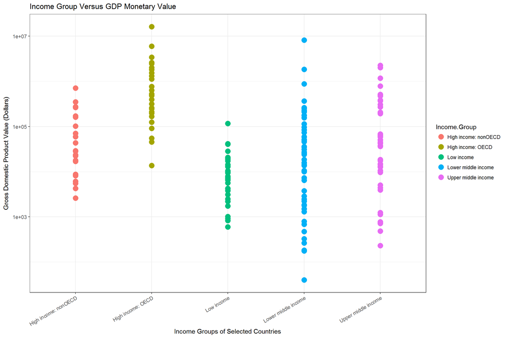

```r
GDPplots <- subset(DataDecendingRank, !is.na(Income.Group))

ggplot(GDPplots, aes(x=Income.Group, y=GDPvalue)) + geom_point(aes(colour = Income.Group), size = 4) +
  scale_y_log10()+
  ggtitle("Income Group Versus GDP Monetary Value") +
  xlab("Income Groups of Selected Countries") +
  ylab("Gross Domestic Product Value (Dollars)") +
  scale_fill_discrete(name="Income Groups") +
  theme_bw()+
  theme( axis.text.x=element_text(angle=30, hjust = 1))
```

## 5. Summary Statistics of GDP by Income Group.

#### For this analysis, each group is separated by income group and each subset is renamed. The summary statistics is then exported as “SummaryStats.txt” to the Analysis for viewing.

```r
LowIncome<- subset(GDPplots, Income.Group == 'Low income')
LowerMiddleIncome<- subset(GDPplots, Income.Group == 'Lower middle income')
UpperMiddleIncome<- subset(GDPplots, Income.Group == 'Upper middle income')
HighIncomeNonOECD2<- subset(GDPplots, Income.Group == 'High income: nonOECD')
HighIncomeOECD2<- subset(GDPplots, Income.Group == 'High income: OECD')

LowIncome<-tapply(LowIncome$GDPvalue, LowIncome$Income.Group, summary, digits = 42)
LowerMiddleIncome<-tapply(LowerMiddleIncome$GDPvalue, LowerMiddleIncome$Income.Group, summary, digits = 42)
UpperMiddleIncome<-tapply(UpperMiddleIncome$GDPvalue, UpperMiddleIncome$Income.Group, summary, digits = 42)
HighIncomeNonOECD<-tapply(HighIncomeNonOECD$GDPvalue, HighIncomeNonOECD$Income.Group, summary, digits = 42)
HighIncomeOECD<-tapply(HighIncomeOECD$GDPvalue, HighIncomeOECD$Income.Group, summary, digits = 42)
SummaryStats<-c(LowIncome,LowerMiddleIncome, UpperMiddleIncome, HighIncomeNonOECD, HighIncomeOECD)
SummaryStats
```

```
## $`Low income`
##      Min.   1st Qu.    Median      Mean   3rd Qu.      Max.
##    596.00   3814.00   7843.00  14410.78  17204.00 116355.00
##
## $`Lower middle income`
##    Min. 1st Qu.  Median    Mean 3rd Qu.    Max.
##      40    2549   24272  256663   81448 8227103
##
## $`Upper middle income`
##      Min.   1st Qu.    Median      Mean   3rd Qu.      Max.
##     228.0    9613.0   42945.0  231847.8  205789.0 2252664.0
##
## $`High income: nonOECD`
##     Min.  1st Qu.   Median     Mean  3rd Qu.     Max.
##   2584.0  12838.0  28373.0 104349.8 131204.5 711050.0
##
## $`High income: OECD`
##     Min.  1st Qu.   Median     Mean  3rd Qu.     Max.
##    13579   211147   486528  1483917  1480047 16244600
```

```r
capture.output(SummaryStats, file = "Analysis/SummaryStats.txt")
```

## 6. Quantiles for GDP Ranking

#### The GDP ranking was cut into 5 separate quantile groups and placed in a table versus income group. From the table, it was determined that the 5 countries from the lower middle income group were amongst the 38 nations with highest GDP. The criteria for determining how to place each country into the different income group doesn’t appear to be solely based on GDP value alone.

#### For the quantile analysis, the “GDPplot” data is renamed “RankQuantile”. The ranking will be divided into 5 groups but first the range of each group is determined. Then the groups are separated into these divisions. The table of GDP ranking separated into 5 separate quantile groups versus income group is exported as “Analysis/RankQuantile.csv” to an external file in Analysis directory.

```r
RankQuantile<-GDPplots
cuts<-quantile(RankQuantile$Ranking, probs = seq(0, 1, 0.2))
RankQuantile<- cut(GDPplots$Ranking, cuts)
RankQuantile<-table(RankQuantile, GDPplots$Income.Group)
RankQuantile
```

```
##
## RankQuantile  High income: nonOECD High income: OECD Low income
##   (1,38.6]                       4                17          0
##   (38.6,76.2]                    5                10          1
##   (76.2,114]                     8                 1          9
##   (114,152]                      4                 1         16
##   (152,190]                      2                 0         11
##
## RankQuantile  Lower middle income Upper middle income
##   (1,38.6]                      5                  11
##   (38.6,76.2]                  13                   9
##   (76.2,114]                   11                   8
##   (114,152]                     9                   8
##   (152,190]                    16                   9
```

```r
write.csv(RankQuantile, "Analysis/RankQuantile.csv")
```

## Further Work

#### This report can be expanded to other years beside 2012 and analyze how ranking and GDP values change over time. Also, review or reevaluate the criteria for income group classification for each economy. Finally, for a true representation of GDP ranking, finding more ways or information about unconfirmed GDP estimated for economies that are not included in the report’s analyses.

#### (1)http://data.worldbank.org/data-catalog/GDP-ranking-table

#### (2)http://data.worldbank.org/data-catalog/ed-stats

#### (3)https://www.thebalance.com/what-is-gdp-definition-of-gross-domestic-product-3306038